# HACKATHON 2021

# Technology and Tech Culture

## Q7. How frequently do you learn a new language or framework?

### All Respondents

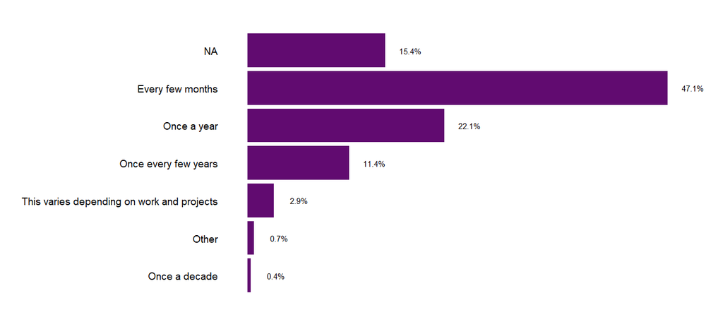

### Professional Developers

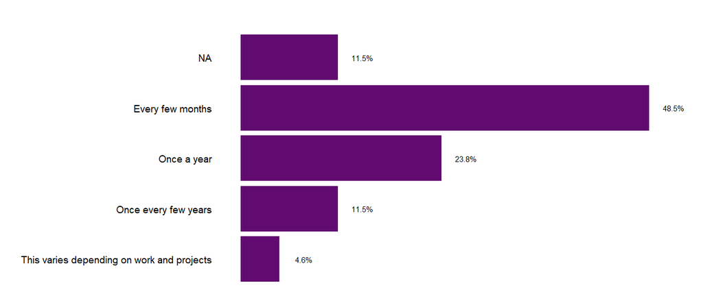

### Students

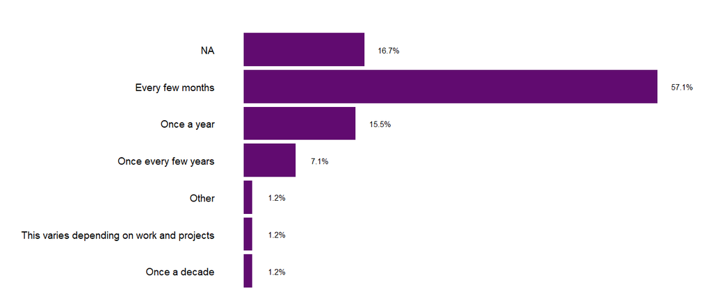

## Q14. What is the primary operating system in which you work?

### All Respondents

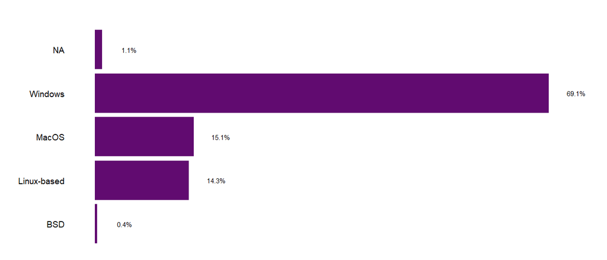

### Professional Developers

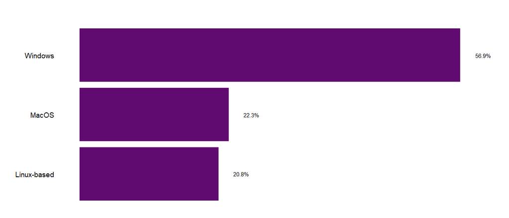

### Students

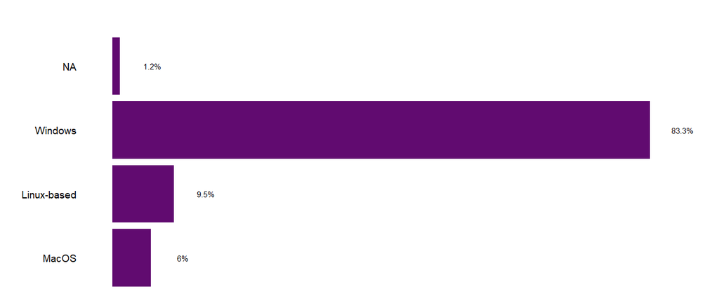

## Q15. In which operating system would you rather work?

### All Respondents

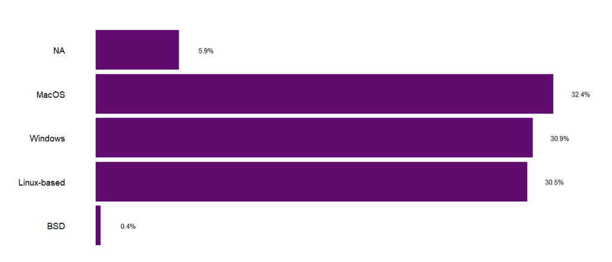

### Professional Developers

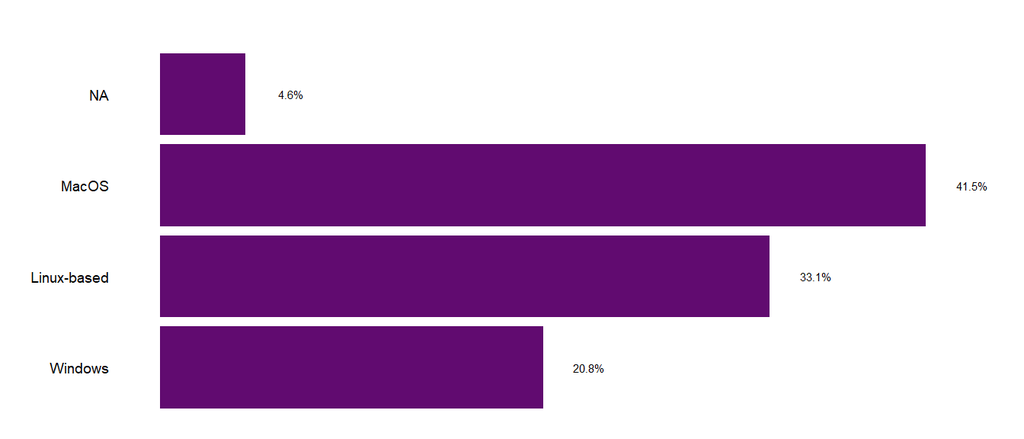

### Students

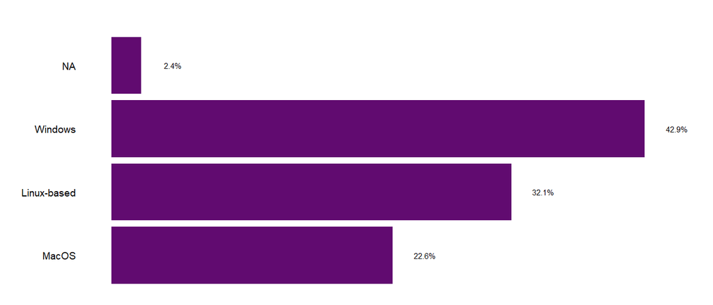

## Q16. What level of influence do you, personally, have over new technology purchases at your organization?

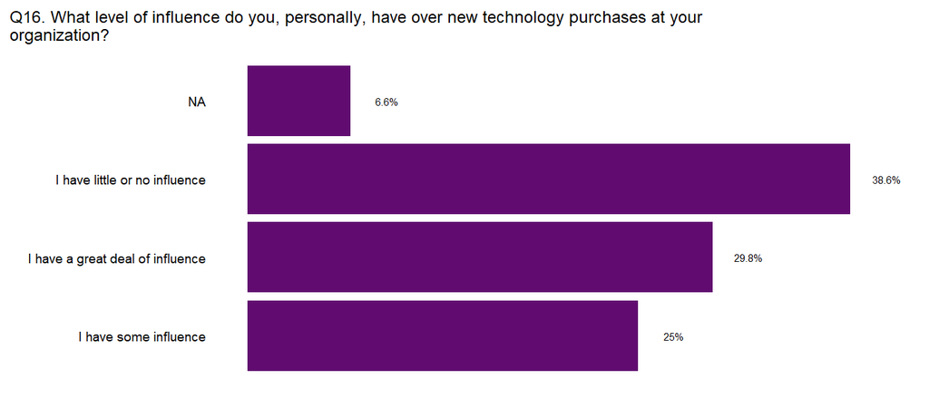

## Q17. When buying a new tool or software, how do you discover and research available solutions? Select all that apply.

[figure not shown]

# Education, Work and Career

## Q18. Which of the following best describes the highest level of formal education that you have completed?

### All Respondents

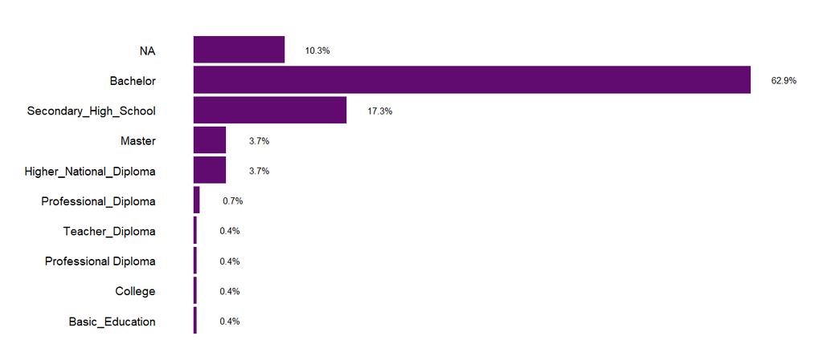

### Professional Developers

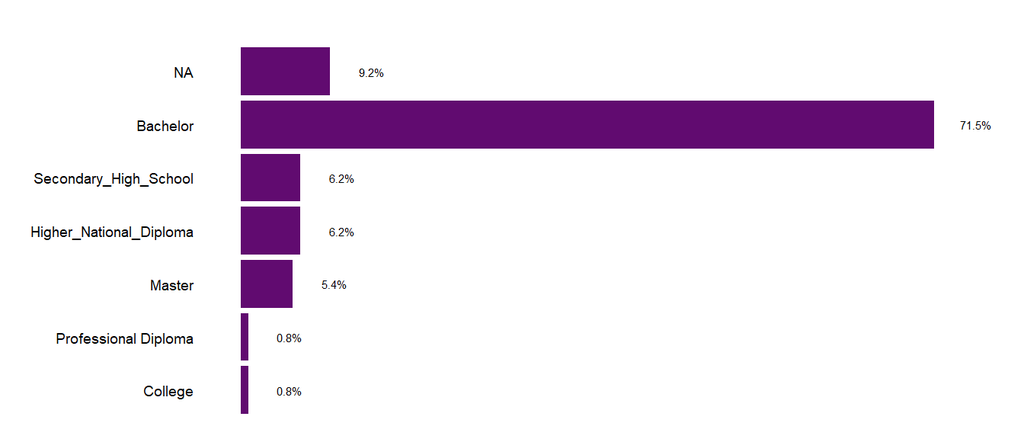

### Students

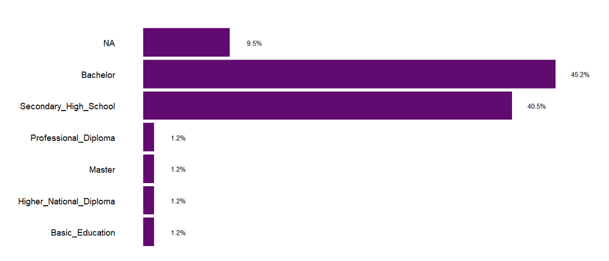

## Q19. What was your primary field of study?

### All Respondents

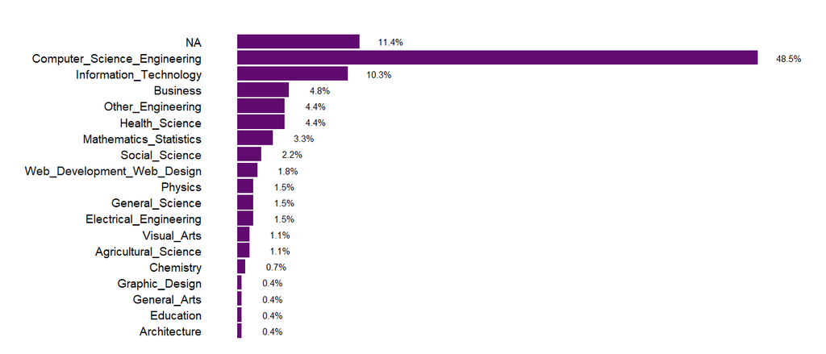

### Professional Developers

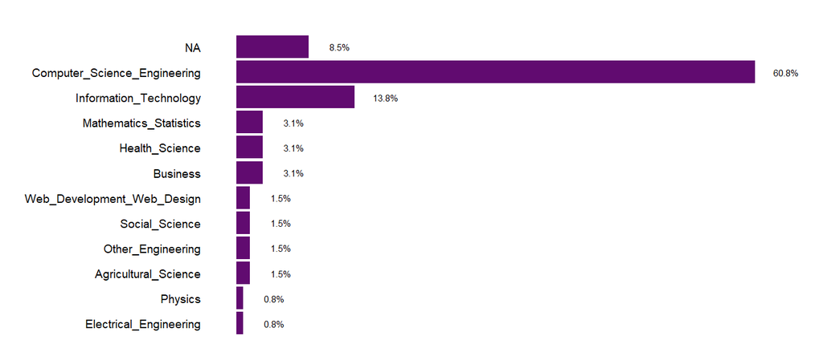

### Students

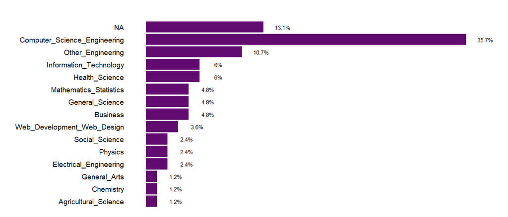

## Q20. How important is a formal education, such as a university degree in computer science, to your career?

### All Respondents

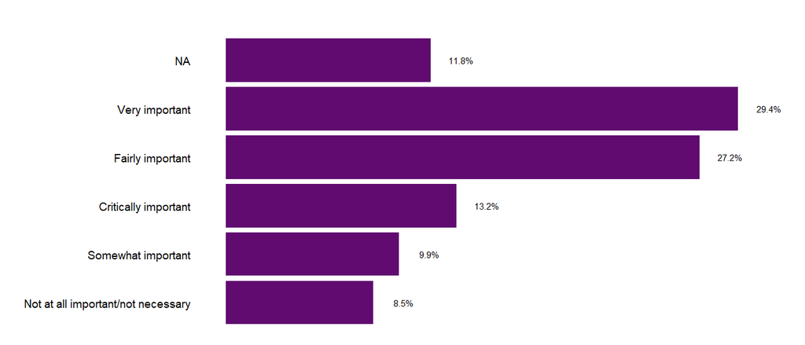

### Professional Developers

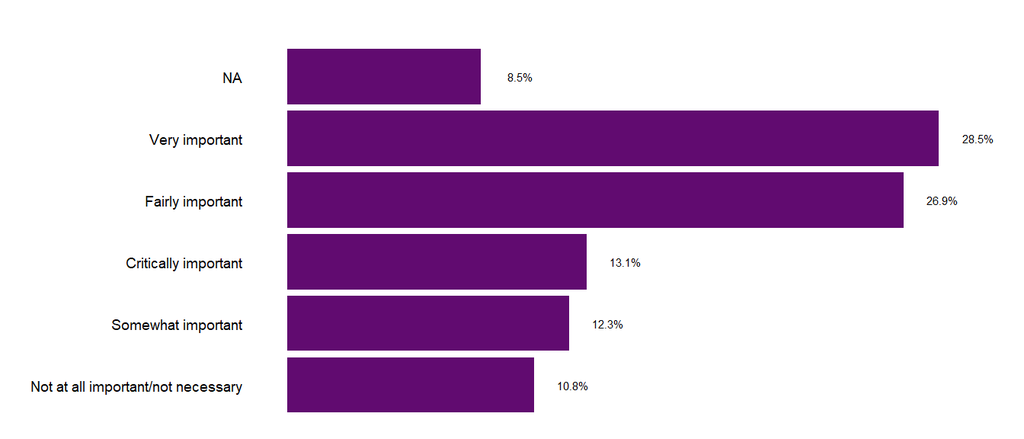

### Students

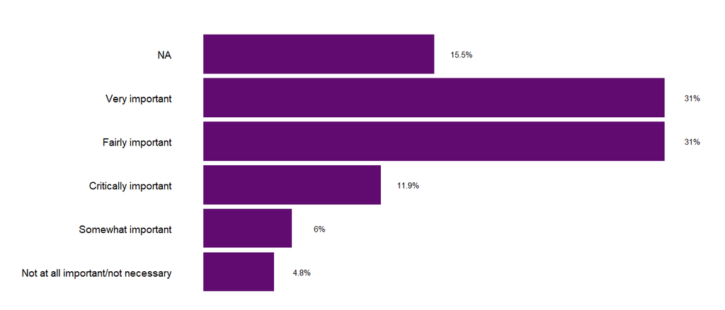

## Q21. From Q18, if you could go back and change your educational path (but end up in the same career), what would you change?

```
##                                                                                                                                    change_edu_21
## 1                                                                                                                           Approach to learning
## 2                                                                                                                     Business or graphic design
## 3                                                                                                                               change my school
## 4                                                                                                 Combination of modules I select for the course
## 5                                                                                                                                     Curriculum
## 6                                                                                                                                 field of study
## 7                                                                                                                      How I learned programming
## 8                                                                                                                     How the courses are taught
## 9  I'd probably have studied general arts in senior high, then turned the Computer Science department ict labs into my playground in University.
## 10                                                                     I'll do electronic and electrical engineering instead of computer science
## 11                                                                                                             I will change the course I chose.
## 12                                                                                                I woud have added something else to my studies
## 13                                                                                                                   I woud not go to university
## 14                                                            I would change my programme of study to computer science, or software engineering.
```

[output cut: 63 more lines]

## Q22. How satisfied are you with your current job? (If you work multiple jobs, answer for one you spend the most hours on.)

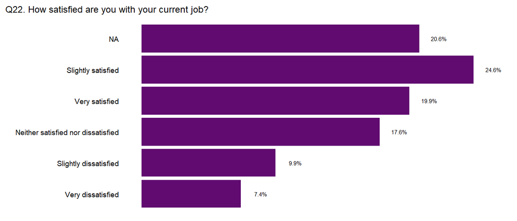

## Q23. Approximately how many people are employed by the company or organization you currently work for?

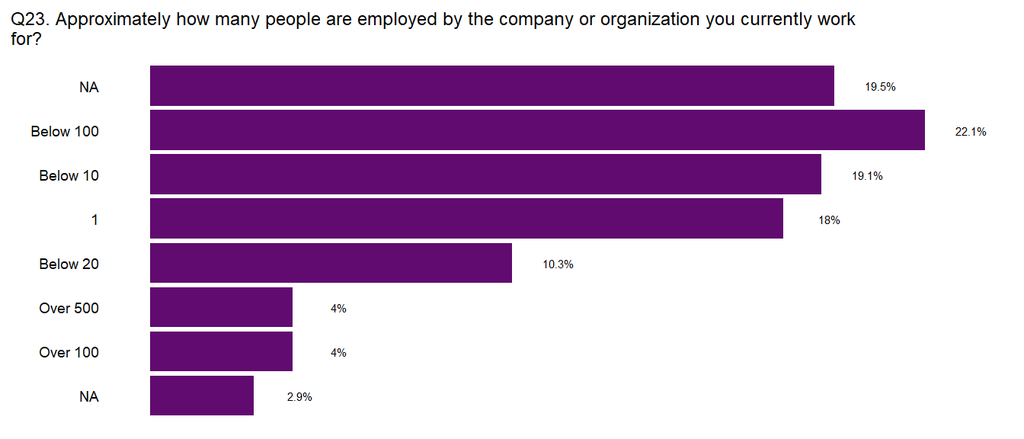

## Q24. On average, how many hours per week do you work? Please enter a whole number in the box.

```
##    weekly_work_hours_24  n        perc perc_label
## 1                     0  2 0.007352941       0.7%
## 2                     2  1 0.003676471       0.4%
## 3                     4  4 0.014705882       1.5%
## 4                     5  4 0.014705882       1.5%
## 5                     6  7 0.025735294       2.6%
## 6                     7  1 0.003676471       0.4%
## 7                     8  6 0.022058824       2.2%
## 8                     9  6 0.022058824       2.2%
## 9                    10  4 0.014705882       1.5%
## 10                   12  4 0.014705882       1.5%
## 11                   15  1 0.003676471       0.4%
## 12                   19  1 0.003676471       0.4%
## 13                   20  6 0.022058824       2.2%
## 14                   21  1 0.003676471       0.4%
```

[output cut: 33 more lines]

## Q25. How often do you work overtime or beyond the formal time expectation of your job?

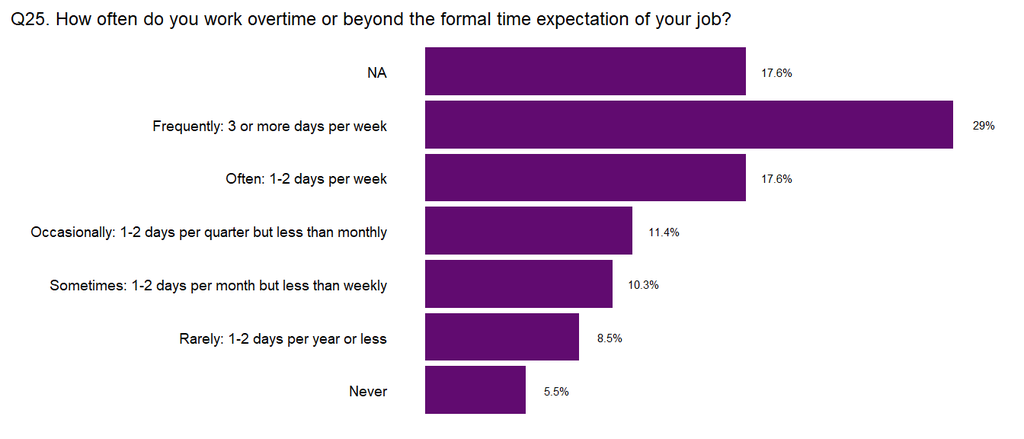

## Q26. Do you think your company has a good on-boarding process? (By on-boarding, we mean the structured process of getting you settled in to your new role at a company)

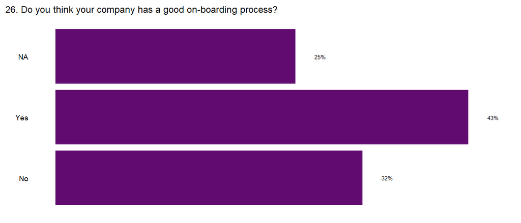

## Q27. How could on-boarding at your company be improved?

```
##                                                                                                           improve_onboarding_27
## 1                                                                           A little interview on the chosen choice of language
## 2                                                                                     A standardized structure for onboard ding
## 3                                                                                             Adequate funds for the right role
## 4                                                                                    Assign mentors to newly assigned employees
## 5                                                                                                       Better background check
## 6                                                                           By applying more practical tests for the individual
## 7                                                       By clearly defining the core functions of the various units/departments
## 8                                                                                    By defining a structure in the first place
## 9                                                                                              By establishing an HR Department
## 10                                                        By improving the organisational structure to facilitate the work flow
## 11                                                                                                            Capacity building
## 12                                                                                                                Communication
## 13 Company needs to allow the organisational structures to work without interference and clear task to be assigned to new hires
## 14                                     Could have someone to take me through the code instead of having to understand it myself
```

[output cut: 119 more lines]

## Q28. How much is your monthly salary in Ghana Cedis?

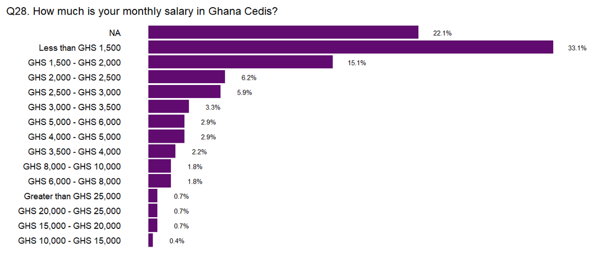

## Q29. Which of the following best describes your current job-seeking status?

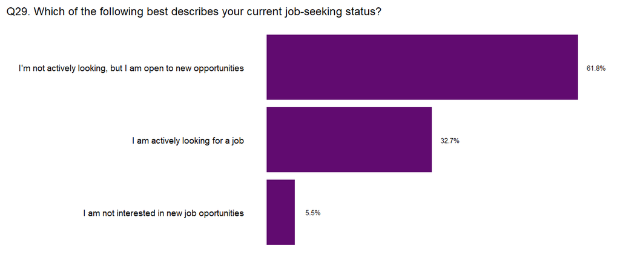

## Q30. In general, what drives you to look for a new job? Select all that apply.

### All Respondents

[figure not shown]

### Professional Developers

[figure not shown]

### Students

[figure not shown]

## Q31. When job searching, how do you learn more about a company? Select all that apply.

[figure not shown]

## Q32. Are you a member of any other online/offline developer communities?

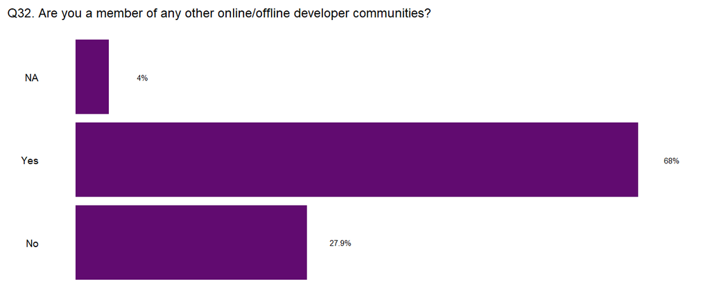

## Q33. Developer communities you are a member of

```
##                                                                                                    which_dev_community_33
## 1                                                                                                   Accra .NET User Group
## 2                                                                                                   Aenics;Diversity Tech
## 3                                                                                               Andela Learning Community
## 4                                                          Andela Learning Community;DevCongress;Laravel Developers Ghana
## 5                       Arduino developer community;Raspberry pi developer community;Stack Exchange;Tensorflow developers
## 6                                                                                     AWS Accra Meetup;Hacklab Foundation
## 7                                                                                               Azubi Africa;Python Ghana
## 8                                                                                                                    Code
## 9                                                                                                                CodeHive
## 10                                                                                                               Codewars
## 11                                                                                                     Dev.to;DevCongress
## 12                                                                                               Dev.to;HackerRank;GitHub
## 13                                                                                                            DevCongress
## 14                                                          DevCongress;Developers in Vogue;Python Ghana;Women TechMakers
```

[output cut: 233 more lines]